# eda_see

### 상관 관계란??

상관관계 수치는 무엇을 의미하나요? 상관관계를 상관 계수라고 하는 단위 없는 척도로 설명하는데, 이 계수는 -1~+1 범위에 있고 r로 표시됩니다. 통계적 유의성은 p 값으로 나타냅니다. 따라서 상관관계는 대개 2개의 키 숫자인 r = 및 p =로 작성됩니다.

- r이 0에 근접할수록 선형 관계가 약해집니다.
- 양수 r 값은 양의 상관관계를 나타냅니다. 여기서 두 변수 값은 함께 증가하는 경향이 있습니다.
- 음수 r 값은 음의 상관관계를 나타냅니다. 여기서 다른 변수 값이 감소할 때 한 변수 값은 증가하는 경향이 있습니다.
- p 값은 표본에서 관측한 것을 기반으로 모집단 상관 계수가 0과 다르다는 유의미한 결론을 내릴 수 있는 근거를 제공합니다.
- "단위 없는 측도"는 상관관계가 자체 척도로 존재한다는 것을 의미합니다. 이 예제에서 r에 제공되는 숫자는 고도 또는 온도와 같은 척도가 아닙니다. 이것은 다른 요약 통계와 다릅니다. 예를 들어 고도 측정치의 평균은 해당 변수와 동일한 척도를 기반으로 합니다.

출처 : https://www.jmp.com/ko_kr/statistics-knowledge-portal/what-is-correlation.html

#### 상관 계수란 어떤 의미를 가질까??

좌표평면을 펼쳐놓고 x 축은 변인 x 를, y 축은 변인 y 를 나타내게 한 뒤 각각의 관찰값들을 산점도 형태로 찍어놓으면, 그 결과 두 변인이 어떤 관계가 있는지 시각적으로 나타나게 된다. 양(+)의 상관이 나타날 경우 관찰값들은 우상향하는 방향으로 모이게 되고, 음(-)의 상관이 나타날 경우 관찰값들은 우하향하는 방향으로 모이게 된다. 그렇지만 관찰값들이 더욱 빽빽하게 밀집해서 모이는 경우가 있고, 조금은 대충대충(?) 흩어져 분포하는 경우가 있는데, 전자의 경우 상관계수가 높다고 말할 수 있고, 후자의 경우 상관계수가 낮다고 말할 수 있다. 그러나 피어슨 상관계수의 값은 반드시 -1에서 1 사이에 위치하게 된다. -1에 가까운 값이 얻어지면 : 누가 봐도 매우 강력한 음(-)의 상관. 오히려 너무 확고하기 때문에 사회과학 데이터일 경우 데이터를 조작한 게 아닌가 의심할 정도이다. 물론 이건 사회과학 얘기고 순수학문에 가까운 분야일수록 요구되는 상관관계는 높은 편.

- -0.5 정도의 값이 얻어지면 : 강력한 음(-)의 상관. 연구자는 변인 x 가 증가하면 변인 y 가 감소한다고 자신 있게 말할 수 있다.
- -0.2 정도의 값이 얻어지면 : 음(-)의 상관이긴 한데 너무 약해서 모호하다. 상관관계가 없다고는 할 수 없지만 좀 더 의심해 봐야 한다.
- 0 정도의 값이 얻어지면 : 대부분의 경우, 상관관계가 있을거라고 간주되지 않는다. 다른 후속 연구들을 통해 뒤집어질지는 모르지만 일단은 회의적이다. 하지만 무조건적으로 그런건 아니라 2차 방정식 그래프와 비슷한 모양이 될 경우 상관관계는 있으나 상관계수는 0에 가깝게 나온다.
- 0.2 정도의 값이 얻어지면 : 너무 약해서 의심스러운 양(+)의 상관. 이것만으로는 상관관계에 대해 아주 장담할 수는 없다. 하지만 사회과학에선 매우 큰 상관관계가 있는 것으로 간주한다.
- 0.5 정도의 값이 얻어지면 : 강력한 양(+)의 상관. 변인 x 가 증가하면 변인 y 가 증가한다는 주장은 이제 통계적으로 지지받고 있다.
- 1에 가까운 값이 얻어지면 : 이상할 정도로 강력한 양(+)의 상관. 위와 마찬가지로, 이렇게까지 확고한 상관관계는 오히려 쉽게 찾아보기 어렵다.

출처 : 나무위키

```python
import pandas as pd
import numpy as np
import matplotlib.pyplot as plt
import seaborn as sns

%matplotlib inline
```

```python
hotel = pd.read_csv("/Users/oyutaeg/Desktop/data/hotel_bookings.csv")
hotel.drop('company', axis='columns', inplace=True)
```

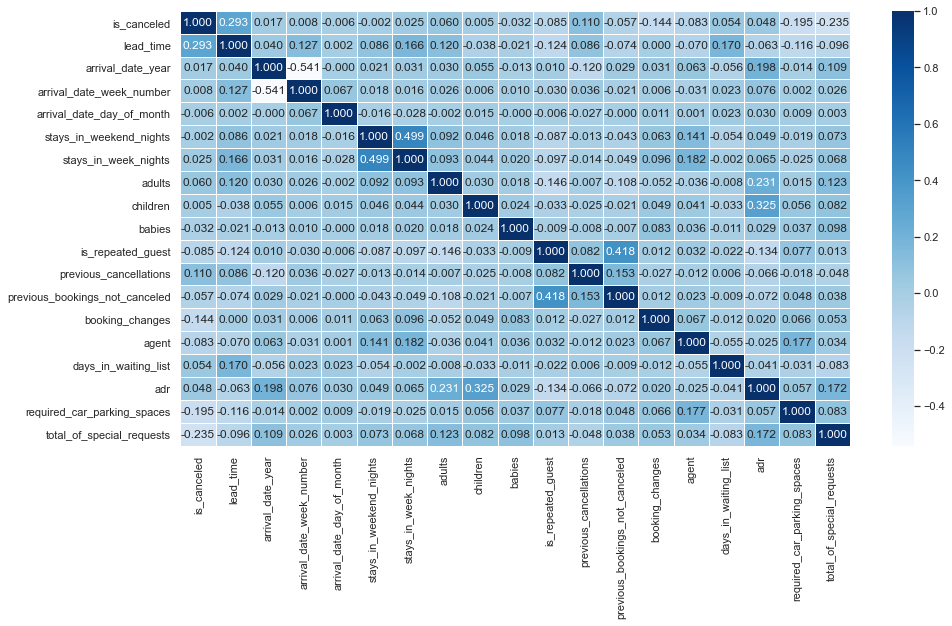

```python
corr = hotel.corr()
plt.figure(figsize=(15, 8))
sns.heatmap(corr, annot=True, fmt='.3f', linewidths=1, cmap='Blues')
plt.show()
```

```python
hotel.corr()["is_canceled"]
```

```
is_canceled                       1.000000
lead_time                         0.293123
arrival_date_year                 0.016660
arrival_date_week_number          0.008148
arrival_date_day_of_month        -0.006130
stays_in_weekend_nights          -0.001791
stays_in_week_nights              0.024765
adults                            0.060017
children                          0.005048
babies                           -0.032491
is_repeated_guest                -0.084793
previous_cancellations            0.110133
previous_bookings_not_canceled   -0.057358
booking_changes                  -0.144381
agent                            -0.083114
days_in_waiting_list              0.054186
adr                               0.047557
required_car_parking_spaces      -0.195498
total_of_special_requests        -0.234658
Name: is_canceled, dtype: float64
```

### 가설 설정

보는 바와같이 호탤예약 취소율에 대한 상관관계를 조사해본결과 역시 돈버는게 쉽지 않다라는 생각이 먼저 듭니다.

위의 설명대로 상관관계 강한 의미를 가지려면 적어도 0.3이상이면 좋겠지만 그래도 0.3에 가까운 칼럼이 2개는 있으니 이 2개에 대한 가설을 세우고 데이터 분석을 진행해 보도록 하겠씁니다.

#### 가설 1.

lead_time 즉 호탤을 예약한 날짜와 실제 호탤을 이용하는 날자 사이의 간극이 클수록 호탤 예약 취소율이 높을것입니.

#### 가설 2.

total_of_special_requests 즉 고객의 특수요청 ex) "신라면 끓여먹어도 되나요?"등 과같은 사항이 많아질 수록 예약 취소율이 줄어들것입니다.

#### 추가 조사

위의 상관계수를 확인해시보면 보는것과 같이 원래의 칼럼이 31개가 있지만 19개만 출력이 되는것을 볼 수 있습니다. 이는 나머지 12개의 칼럼이 수치형 자료가 아니기때문에 누락이 되었는데 그 중에서도 충분히 의미있는 칼럼이 존재하므로 이번 분석에서는 customer_type과 deposit_type의 시각화 역시도 같이 진행해 보도록 하겠습니다.